# Comparação de Modelos de Sinistros

Negative Binomial vs Random Forest vs SP-NB Queen

2026-10-05

# 1 1. Objetivo

O objetivo é comparar três abordagens para prever o número mensal de sinistros em cada grid:

1. **Negative Binomial (NB)**;
2. **Random Forest (RF)**;
3. **Spatio-Temporal Negative Binomial com adjacência Queen (SP-NB Queen)**.

A unidade observacional é:

$$\boxed{
\text{grid} \times \text{mês}
}$$

A variável resposta é:

$$Y_{g,t}
=
\text{número de sinistros no grid }g
\text{ no mês }t.$$

A exposição é:

$$E_{g,t}
=
\text{número de domicílios segurados no grid}.$$

O benchmark Negative Binomial utiliza:

$$\lambda_{g,t}
=
E_{g,t}
\exp(\beta^\top X_{g,t}).$$

O modelo espaço-temporal utiliza:

$$\lambda_{g,t}
=
E_{g,t}
\left[
\exp(\beta^\top X_{g,t})
+
\psi_g
(A_Q\bar Y_{t-1})_g
\right].$$

# 2 2. Leitura e validação da base

Resumo da base utilizada

| Indicador | Valor |
| --- | --- |
| Observações | 7500 |
| Grids | 25 |
| Meses | 300 |
| Sinistros totais | 12855 |
| Exposição média mensal | 15000 |

# 3 3. Divisão temporal entre treino e teste

Divisão temporal da amostra

| Amostra | Periodo | Observacoes | Sinistros |
| --- | --- | --- | --- |
| Treino | 2001-2020 | 6000 | 9954 |
| Teste | 2021-2025 | 1500 | 2901 |

# 4 4. Modelo 1 — Negative Binomial

# 5 5. Modelo 2 — Random Forest

O Random Forest é utilizado como benchmark de machine learning para capturar relações não lineares e interações entre as covariáveis.

# 6 6. Construção da matriz Queen

# 7 7. Componente espaço-temporal

# 8 8. Matriz de covariáveis do SP-NB

# 9 9. Funções do SP-NB Queen

# 10 10. Algoritmo EM

# 11 11. Estimação do SP-NB Queen

# 12 12. Métricas preditivas

Desempenho preditivo no período de teste

| Modelo | Observado | Previsto | Balance | MAE | RMSE | R2 | Correlacao |
| --- | --- | --- | --- | --- | --- | --- | --- |
| Negative Binomial | 2901 | 3036.961 | 1.0469 | 1.1807 | 2.0960 | 0.7531 | 0.8684 |
| Random Forest | 2901 | 2649.959 | 0.9135 | 1.2666 | 3.0353 | 0.4822 | 0.7538 |
| SP-NB Queen | 2901 | 3023.738 | 1.0423 | 1.1670 | 2.0877 | 0.7550 | 0.8692 |

# 13 13. Melhora relativa versus Negative Binomial

Melhora preditiva em relação à Negative Binomial

| Modelo | RMSE | Melhora_RMSE_vs_NB | MAE | Melhora_MAE_vs_NB |
| --- | --- | --- | --- | --- |
| Negative Binomial | 2.10 | 0.00 | 1.18 | 0.00 |
| Random Forest | 3.04 | -44.81 | 1.27 | -7.27 |
| SP-NB Queen | 2.09 | 0.40 | 1.17 | 1.16 |

# 14 14. Sinistros observados e previstos por grid

Sinistros observados e previstos por grid

| id_celula | linha | coluna | Observado | NB | RF | SP_NB |
| --- | --- | --- | --- | --- | --- | --- |
| R+0_C+0 | 0 | 0 | 62 | 84.22 | 82.74 | 87.65 |
| R+0_C+1 | 0 | 1 | 79 | 69.88 | 67.96 | 71.28 |
| R+0_C+2 | 0 | 2 | 148 | 191.88 | 174.17 | 188.82 |
| R+0_C-1 | 0 | -1 | 103 | 111.70 | 111.41 | 114.59 |
| R+0_C-2 | 0 | -2 | 131 | 122.63 | 102.49 | 116.59 |
| R+1_C+0 | 1 | 0 | 148 | 139.30 | 118.49 | 139.56 |
| R+1_C+1 | 1 | 1 | 101 | 88.84 | 96.43 | 93.11 |
| R+1_C+2 | 1 | 2 | 131 | 160.54 | 135.06 | 158.28 |
| R+1_C-1 | 1 | -1 | 237 | 207.68 | 168.23 | 212.02 |
| R+1_C-2 | 1 | -2 | 93 | 98.52 | 89.60 | 96.72 |
| R+2_C+0 | 2 | 0 | 145 | 146.44 | 111.52 | 146.64 |
| R+2_C+1 | 2 | 1 | 93 | 79.99 | 77.42 | 84.03 |
| R+2_C+2 | 2 | 2 | 245 | 269.64 | 194.76 | 265.42 |
| R+2_C-1 | 2 | -1 | 107 | 138.81 | 113.91 | 135.27 |
| R+2_C-2 | 2 | -2 | 97 | 120.46 | 95.55 | 117.21 |
| R-1_C+0 | -1 | 0 | 135 | 148.36 | 121.46 | 146.27 |
| R-1_C+1 | -1 | 1 | 87 | 87.01 | 87.58 | 90.22 |
| R-1_C+2 | -1 | 2 | 58 | 54.97 | 59.91 | 54.74 |
| R-1_C-1 | -1 | -1 | 124 | 100.57 | 87.60 | 101.03 |
| R-1_C-2 | -1 | -2 | 106 | 116.67 | 96.16 | 110.85 |
| R-2_C+0 | -2 | 0 | 88 | 113.98 | 98.56 | 111.93 |
| R-2_C+1 | -2 | 1 | 70 | 71.23 | 71.25 | 71.49 |
| R-2_C+2 | -2 | 2 | 146 | 136.50 | 125.59 | 133.52 |
| R-2_C-1 | -2 | -1 | 88 | 93.30 | 85.02 | 92.25 |
| R-2_C-2 | -2 | -2 | 79 | 83.83 | 77.10 | 84.25 |

# 15 15. Acurácia percentual por grid

A acurácia espacial é definida como:

$$Accuracy_g
=
100
\left(
1-
\frac{
|Y_g-\hat Y_g|
}{
Y_g
}
\right).$$

Valores negativos são truncados em zero.

Assim:

- **100%** = previsão agregada exatamente igual ao observado;
- **90%** = erro absoluto equivalente a 10% do observado;
- **50%** = erro equivalente a 50% do observado;
- **0%** = erro igual ou superior ao observado.

Acurácia percentual por grid

| id_celula | Observado | Accuracy_NB | Accuracy_RF | Accuracy_SP |
| --- | --- | --- | --- | --- |
| R+0_C+0 | 62 | 64.2 | 66.6 | 58.6 |
| R+0_C+1 | 79 | 88.5 | 86.0 | 90.2 |
| R+0_C+2 | 148 | 70.4 | 82.3 | 72.4 |
| R+0_C-1 | 103 | 91.5 | 91.8 | 88.7 |
| R+0_C-2 | 131 | 93.6 | 78.2 | 89.0 |
| R+1_C+0 | 148 | 94.1 | 80.1 | 94.3 |
| R+1_C+1 | 101 | 88.0 | 95.5 | 92.2 |
| R+1_C+2 | 131 | 77.5 | 96.9 | 79.2 |
| R+1_C-1 | 237 | 87.6 | 71.0 | 89.5 |
| R+1_C-2 | 93 | 94.1 | 96.3 | 96.0 |
| R+2_C+0 | 145 | 99.0 | 76.9 | 98.9 |
| R+2_C+1 | 93 | 86.0 | 83.3 | 90.4 |
| R+2_C+2 | 245 | 89.9 | 79.5 | 91.7 |
| R+2_C-1 | 107 | 70.3 | 93.5 | 73.6 |
| R+2_C-2 | 97 | 75.8 | 98.5 | 79.2 |
| R-1_C+0 | 135 | 90.1 | 90.0 | 91.7 |
| R-1_C+1 | 87 | 100.0 | 99.3 | 96.3 |
| R-1_C+2 | 58 | 94.8 | 96.7 | 94.4 |
| R-1_C-1 | 124 | 81.1 | 70.6 | 81.5 |
| R-1_C-2 | 106 | 89.9 | 90.7 | 95.4 |
| R-2_C+0 | 88 | 70.5 | 88.0 | 72.8 |
| R-2_C+1 | 70 | 98.2 | 98.2 | 97.9 |
| R-2_C+2 | 146 | 93.5 | 86.0 | 91.5 |
| R-2_C-1 | 88 | 94.0 | 96.6 | 95.2 |
| R-2_C-2 | 79 | 93.9 | 97.6 | 93.4 |

# 16 16. Grid 5x5 — Negative Binomial

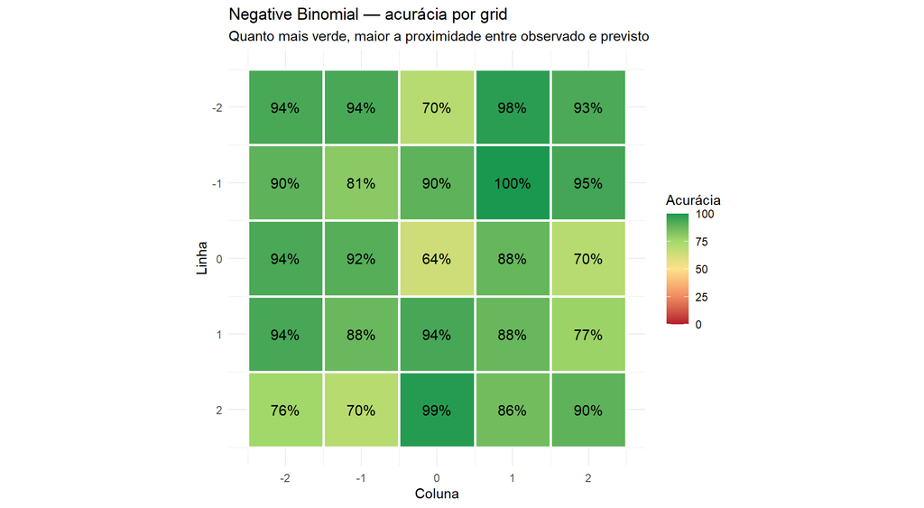

# 17 17. Grid 5x5 — Random Forest

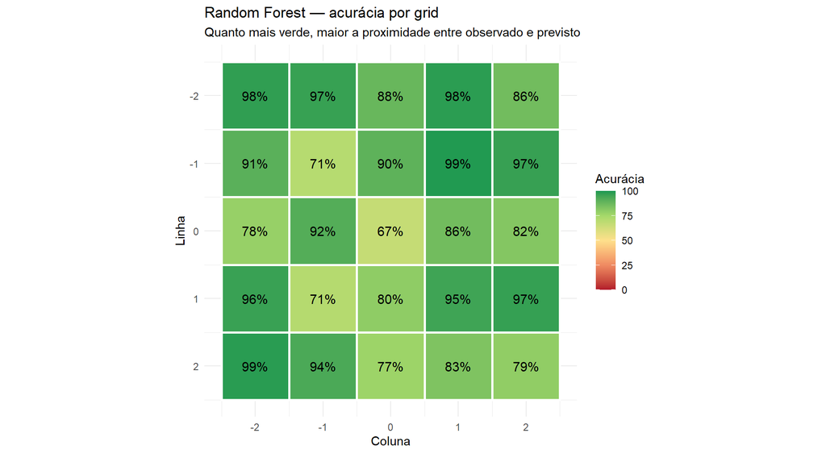

# 18 18. Grid 5x5 — SP-NB Queen

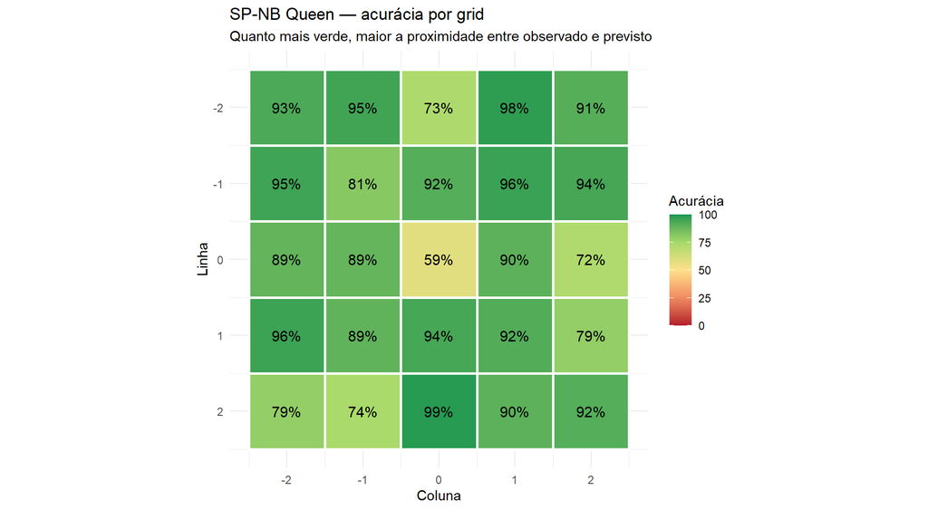

# 19 19. Acurácia espacial média

Desempenho espacial entre os 25 grids

| Modelo | Accuracy_media | Accuracy_mediana | Grids_acima_90pct |
| --- | --- | --- | --- |
| Negative Binomial | 87.1 | 89.9 | 12 |
| Random Forest | 87.6 | 90.0 | 12 |
| SP-NB Queen | 87.7 | 91.5 | 15 |

# 20 20. Observado versus previsto por grid

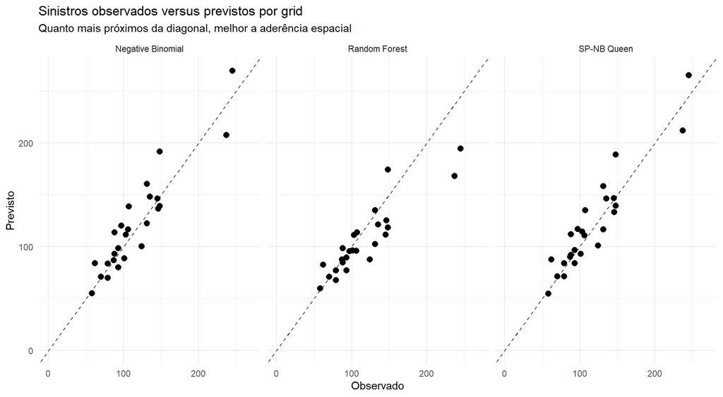

# 21 21. Métricas no nível do grid

Desempenho agregado no nível dos grids

| Modelo | MAE_Grid | RMSE_Grid | Correlacao_Grid |
| --- | --- | --- | --- |
| Negative Binomial | 14.7690 | 18.5939 | 0.9277 |
| Random Forest | 16.4876 | 23.5431 | 0.9009 |
| SP-NB Queen | 13.7984 | 17.2325 | 0.9357 |

# 22 22. Comparação temporal

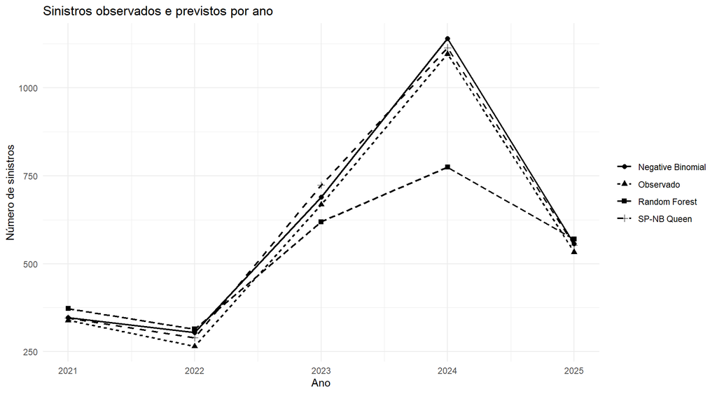

# 23 23. Importância das variáveis — Random Forest

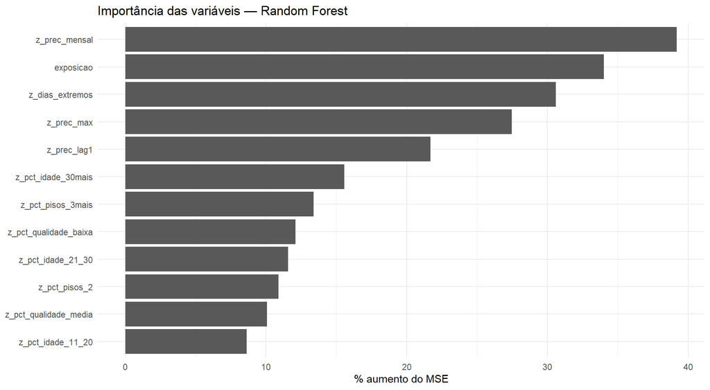

# 24 24. Coeficientes da Negative Binomial e SP-NB

Coeficientes dos modelos paramétricos

| Variavel | Negative_Binomial | SP_NB_Queen |
| --- | --- | --- |
| Intercepto | -6.09960 | -6.21106 |
| z_prec_mensal | 0.27595 | 0.31320 |
| z_prec_max | 0.19451 | 0.21237 |
| z_dias_extremos | 0.17760 | 0.17909 |
| z_prec_lag1 | 0.18595 | 0.10491 |
| z_pct_pisos_2 | 0.07395 | 0.07307 |
| z_pct_pisos_3mais | 0.10653 | 0.09748 |
| z_pct_qualidade_media | 0.07055 | 0.08713 |
| z_pct_qualidade_baixa | 0.16250 | 0.17970 |
| z_pct_idade_11_20 | -0.01238 | -0.00953 |
| z_pct_idade_21_30 | 0.08437 | 0.08873 |
| z_pct_idade_30mais | 0.12006 | 0.12279 |

# 25 25. Efeito espacial estimado por grid

Efeito espaço-temporal estimado por grid

| id_celula | psi_estimado | vizinhos_queen | psi_true |
| --- | --- | --- | --- |
| R-2_C-2 | 0.0002738 | 3 | 0.0002244 |
| R-2_C-1 | 0.0002304 | 5 | 0.0002325 |
| R-2_C+0 | 0.0002577 | 5 | 0.0001950 |
| R-2_C+1 | 0.0002591 | 5 | 0.0002064 |
| R-2_C+2 | 0.0002044 | 3 | 0.0001997 |
| R-1_C-2 | 0.0001814 | 5 | 0.0002753 |
| R-1_C-1 | 0.0001692 | 8 | 0.0001802 |
| R-1_C+0 | 0.0001841 | 8 | 0.0001988 |
| R-1_C+1 | 0.0003232 | 8 | 0.0002142 |
| R-1_C+2 | 0.0001792 | 5 | 0.0002177 |
| R+0_C-2 | 0.0000805 | 5 | 0.0001904 |
| R+0_C-1 | 0.0001294 | 8 | 0.0002531 |
| R+0_C+0 | 0.0003817 | 8 | 0.0001797 |
| R+0_C+1 | 0.0001806 | 8 | 0.0002504 |
| R+0_C+2 | 0.0003686 | 5 | 0.0002901 |
| R+1_C-2 | 0.0002478 | 5 | 0.0002533 |
| R+1_C-1 | 0.0002360 | 8 | 0.0002813 |
| R+1_C+0 | 0.0002658 | 8 | 0.0002283 |
| R+1_C+1 | 0.0003517 | 8 | 0.0002409 |
| R+1_C+2 | 0.0002168 | 5 | 0.0002270 |
| R+2_C-2 | 0.0003709 | 3 | 0.0001940 |
| R+2_C-1 | 0.0002888 | 5 | 0.0001824 |
| R+2_C+0 | 0.0002822 | 5 | 0.0002788 |
| R+2_C+1 | 0.0003843 | 5 | 0.0002063 |
| R+2_C+2 | 0.0004867 | 3 | 0.0002827 |

# 26 26. Recuperação do efeito espacial

Recuperação do efeito espacial verdadeiro

| Indicador | Valor |
| --- | --- |
| Correlação psi verdadeiro vs estimado | 0.155843 |
| MAE do psi | 0.000076 |

# 27 27. Convergência do SP-NB Queen

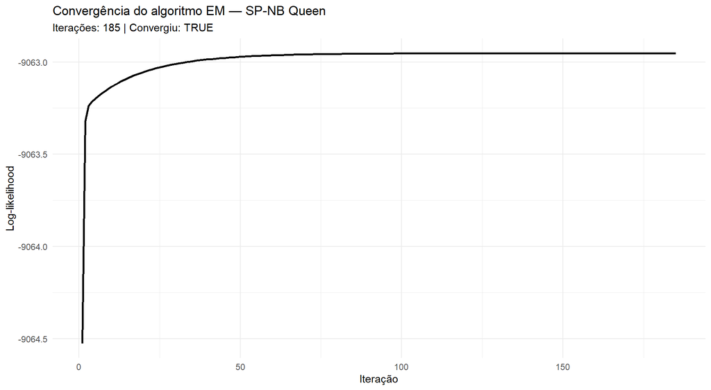

# 28 28. Resultado consolidado

Resumo dos melhores modelos por critério

| Indicador | Melhor_modelo |
| --- | --- |
| Menor RMSE mensal | SP-NB Queen |
| Menor MAE mensal | SP-NB Queen |
| Maior R² | SP-NB Queen |
| Maior acurácia média por grid | SP-NB Queen |
| Menor RMSE agregado por grid | SP-NB Queen |

# 29 29. Interpretação dos resultados

A comparação entre os três modelos deve considerar diferentes dimensões.

**Negative Binomial** funciona como benchmark estatístico paramétrico. O modelo pressupõe uma estrutura funcional explícita entre as covariáveis e a frequência de sinistros.

**Random Forest** permite relações não lineares e interações entre as variáveis sem impor previamente uma forma funcional.

**SP-NB Queen** mantém a estrutura probabilística da Negative Binomial e adiciona explicitamente a informação de ocorrência anormal de sinistros nos grids vizinhos no período anterior.

As métricas mensais avaliam a qualidade da previsão em cada observação grid-mês.

Os grids 5x5 avaliam uma dimensão diferente: se o modelo consegue distribuir corretamente o volume acumulado de sinistros entre as diferentes regiões.

Um modelo pode, portanto, apresentar bom resultado global e ainda possuir erros localizados espacialmente. Por isso, o diagnóstico deve considerar conjuntamente:

- MAE;
- RMSE;
- $R^2$;
- correlação;
- balance;
- acurácia por grid;
- RMSE por grid;
- evolução temporal.

# 30 30. Exportação dos resultados